# Reproducible Data Analysis Project

u3232147

## Introduction

The National Basketball League (NBA) is the premier men’s professional basketball league in North America. The league comprises 30 teams. The game is played by two teams, five players each, with the aim to shoot a ball through the opponent’s hoop, while preventing the other team from shooting the ball through the team’s own hoop. The five players each have a different position:

**1. Point Guard** - usually a shorter player, and a good ball handler and passer.

**2. Shooting Guard** - a player who creates openings and generally shoots from the three-point range.

**3. Small Forward** - aggressive players who drive to the basket and who may try to draw fouls.

**4. Power Forward** - the team’s most dependent scorer and most commonly scores from close to the basket.

**5. Centre** - usually the tallest player on the team, who plays close to the basket and is skilled at rebounds and contesting shots.

The Chicago Bulls is one of the 30 NBA teams. In the 2018-19 season, the team was ranked 27th based on their win-loss record. Player contracts for the 2019-20 season are currently being reviewed in order to improve the performance. It is believed that by changing the team’s five starting players, the team’s performance can improve.

The purpose of this report is to provide the General Manager of the Chicago Bulls NBA team the best five starting players the team can afford within the $118,000,000 budget for the 2019-20 season.

## Reading and Cleaning the Raw Data

### Load the required packages

```r
library(tidyverse)
library(broom)
library(plyr)
library(plotly)
```

### Data Source

The data used for this analysis contains player, statistics, team statistics and player salaries for the 2018-19 season. The data also contains the team payroll for the 2019-20 season. It has been sourced from:

- Player and team statistics: [sourced from basketball-reference.com] (basketball-reference.com)
- Player salaries and team payroll: [sourced from hoopshype.com/salaries] (hoopshype.com/salaries)

### Read Data

Read in the source files using the `read_csv()` function from the `readr` package.

```r
# read in the data
nba_player_salary <- read_csv("data/raw/2018-19_nba_player-salaries.csv")
nba_player_stats <- read_csv("data/raw/2018-19_nba_player-statistics.csv")
nba_team_stats1 <- read_csv("data/raw/2018-19_nba_team-statistics_1.csv")
nba_team_stats2 <- read_csv("data/raw/2018-19_nba_team-statistics_2.csv")
nba_team_payroll <- read_csv("data/raw/2019-20_nba_team-payroll.csv")
```

### Check and Clean the data

Check the structure of the data using str() and view the data in the console

```r
str(nba_player_salary)
```

```
## spec_tbl_df [576 x 3] (S3: spec_tbl_df/tbl_df/tbl/data.frame)
##  $ player_id  : num [1:576] 1 2 3 4 5 6 7 8 9 10 ...
##  $ player_name: chr [1:576] "Alex Abrines" "Quincy Acy" "Steven Adams" "Jaylen Adams" ...
##  $ salary     : num [1:576] 3667645 213948 24157304 236854 2955840 ...
##  - attr(*, "spec")=
##   .. cols(
##   ..   player_id = col_double(),
##   ..   player_name = col_character(),
##   ..   salary = col_double()
##   .. )
```

```r
str(nba_player_stats)
```

```
## spec_tbl_df [708 x 29] (S3: spec_tbl_df/tbl_df/tbl/data.frame)
##  $ player_name: chr [1:708] "Alex Abrines" "Quincy Acy" "Jaylen Adams" "Steven Adams" ...
##  $ Pos        : chr [1:708] "SG" "PF" "PG" "C" ...
##  $ Age        : num [1:708] 25 28 22 25 21 21 25 33 21 23 ...
##  $ Tm         : chr [1:708] "OKC" "PHO" "ATL" "OKC" ...
##  $ G          : num [1:708] 31 10 34 80 82 19 7 81 10 38 ...
##  $ GS         : num [1:708] 2 0 1 80 28 3 0 81 1 2 ...
##  $ MP         : num [1:708] 588 123 428 2669 1913 ...
##  $ FG         : num [1:708] 56 4 38 481 280 11 3 684 13 67 ...
##  $ FGA        : num [1:708] 157 18 110 809 486 ...
##  $ FG%        : num [1:708] 0.357 0.222 0.345 0.595 0.576 0.306 0.3 0.519 0.333 0.376 ...
##  $ 3P         : num [1:708] 41 2 25 0 3 6 0 10 3 32 ...
##  $ 3PA        : num [1:708] 127 15 74 2 15 23 4 42 12 99 ...
##  $ 3P%        : num [1:708] 0.323 0.133 0.338 0 0.2 0.261 0 0.238 0.25 0.323 ...
##  $ 2P         : num [1:708] 15 2 13 481 277 5 3 674 10 35 ...
##  $ 2PA        : num [1:708] 30 3 36 807 471 ...
##  $ 2P%        : num [1:708] 0.5 0.667 0.361 0.596 0.588 0.385 0.5 0.528 0.37 0.443 ...
##  $ eFG%       : num [1:708] 0.487 0.278 0.459 0.595 0.579 0.389 0.3 0.522 0.372 0.466 ...
##  $ FT         : num [1:708] 12 7 7 146 166 4 1 349 8 45 ...
##  $ FTA        : num [1:708] 13 10 9 292 226 4 2 412 12 60 ...
##  $ FT%        : num [1:708] 0.923 0.7 0.778 0.5 0.735 1 0.5 0.847 0.667 0.75 ...
##  $ ORB        : num [1:708] 5 3 11 391 165 3 1 251 11 3 ...
##  $ DRB        : num [1:708] 43 22 49 369 432 16 3 493 15 20 ...
##  $ TRB        : num [1:708] 48 25 60 760 597 19 4 744 26 23 ...
##  $ AST        : num [1:708] 20 8 65 124 184 5 6 194 13 25 ...
##  $ STL        : num [1:708] 17 1 14 117 71 1 2 43 1 6 ...
##  $ BLK        : num [1:708] 6 4 5 76 65 4 0 107 0 6 ...
##  $ TOV        : num [1:708] 14 4 28 135 121 6 2 144 8 33 ...
##  $ PF         : num [1:708] 53 24 45 204 203 13 4 179 7 47 ...
##  $ PTS        : num [1:708] 165 17 108 1108 729 ...
##  - attr(*, "spec")=
##   .. cols(
##   ..   player_name = col_character(),
##   ..   Pos = col_character(),
##   ..   Age = col_double(),
##   ..   Tm = col_character(),
##   ..   G = col_double(),
##   ..   GS = col_double(),
##   ..   MP = col_double(),
##   ..   FG = col_double(),
##   ..   FGA = col_double(),
##   ..   `FG%` = col_double(),
##   ..   `3P` = col_double(),
##   ..   `3PA` = col_double(),
##   ..   `3P%` = col_double(),
##   ..   `2P` = col_double(),
##   ..   `2PA` = col_double(),
##   ..   `2P%` = col_double(),
##   ..   `eFG%` = col_double(),
##   ..   FT = col_double(),
##   ..   FTA = col_double(),
##   ..   `FT%` = col_double(),
##   ..   ORB = col_double(),
##   ..   DRB = col_double(),
##   ..   TRB = col_double(),
##   ..   AST = col_double(),
##   ..   STL = col_double(),
##   ..   BLK = col_double(),
##   ..   TOV = col_double(),
##   ..   PF = col_double(),
##   ..   PTS = col_double()
##   .. )
```

```r
str(nba_team_stats1)
```

```
## spec_tbl_df [30 x 25] (S3: spec_tbl_df/tbl_df/tbl/data.frame)
##  $ Rk    : num [1:30] 1 2 3 4 5 6 7 8 9 10 ...
##  $ Team  : chr [1:30] "Milwaukee Bucks" "Golden State Warriors" "Toronto Raptors" "Utah Jazz" ...
##  $ Age   : num [1:30] 26.9 28.4 27.3 27.3 29.2 26.2 24.9 25.7 25.7 27 ...
##  $ W     : num [1:30] 60 57 58 50 53 53 54 49 49 48 ...
##  $ L     : num [1:30] 22 25 24 32 29 29 28 33 33 34 ...
##  $ PW    : num [1:30] 61 56 56 54 53 51 51 52 50 50 ...
##  $ PL    : num [1:30] 21 26 26 28 29 31 31 30 32 32 ...
##  $ MOV   : num [1:30] 8.87 6.46 6.09 5.26 4.77 4.2 3.95 4.44 3.4 3.33 ...
##  $ SOS   : num [1:30] -0.82 -0.04 -0.6 0.03 0.19 0.24 0.24 -0.54 0.15 -0.57 ...
##  $ SRS   : num [1:30] 8.04 6.42 5.49 5.28 4.96 4.43 4.19 3.9 3.56 2.76 ...
##  $ ORtg  : num [1:30] 114 116 113 111 116 ...
##  $ DRtg  : num [1:30] 105 110 107 106 111 ...
##  $ NRtg  : num [1:30] 8.6 6.4 6 5.2 4.8 4.2 4.1 4.4 3.3 3.4 ...
##  $ Pace  : num [1:30] 103.3 100.9 100.2 100.3 97.9 ...
##  $ FTr   : num [1:30] 0.255 0.227 0.247 0.295 0.279 0.258 0.232 0.215 0.266 0.242 ...
##  $ 3PAr  : num [1:30] 0.419 0.384 0.379 0.394 0.519 0.339 0.348 0.381 0.347 0.292 ...
##  $ TS%   : num [1:30] 0.583 0.596 0.579 0.572 0.581 0.568 0.558 0.567 0.545 0.561 ...
##  $ eFG%  : num [1:30] 0.55 0.565 0.543 0.538 0.542 0.528 0.527 0.534 0.514 0.53 ...
##  $ TOV%  : num [1:30] 12 12.6 12.4 13.4 12 12.1 11.9 11.5 11.7 12.4 ...
##  $ ORB%  : num [1:30] 20.8 22.5 21.9 22.9 22.8 26.6 26.6 21.6 26 21.9 ...
##  $ FT/FGA: num [1:30] 0.197 0.182 0.198 0.217 0.221 0.21 0.175 0.173 0.19 0.182 ...
##  $ DRB%  : num [1:30] 80.3 77.1 77.1 80.3 74.4 77.9 78 77 78.2 76.2 ...
##  $ X23   : logi [1:30] NA NA NA NA NA NA ...
##  $ X24   : logi [1:30] NA NA NA NA NA NA ...
##  $ X25   : logi [1:30] NA NA NA NA NA NA ...
##  - attr(*, "spec")=
##   .. cols(
##   ..   Rk = col_double(),
##   ..   Team = col_character(),
##   ..   Age = col_double(),
##   ..   W = col_double(),
##   ..   L = col_double(),
##   ..   PW = col_double(),
##   ..   PL = col_double(),
##   ..   MOV = col_double(),
##   ..   SOS = col_double(),
##   ..   SRS = col_double(),
##   ..   ORtg = col_double(),
##   ..   DRtg = col_double(),
##   ..   NRtg = col_double(),
##   ..   Pace = col_double(),
##   ..   FTr = col_double(),
##   ..   `3PAr` = col_double(),
##   ..   `TS%` = col_double(),
##   ..   `eFG%` = col_double(),
##   ..   `TOV%` = col_double(),
##   ..   `ORB%` = col_double(),
##   ..   `FT/FGA` = col_double(),
##   ..   `DRB%` = col_double(),
##   ..   X23 = col_logical(),
##   ..   X24 = col_logical(),
##   ..   X25 = col_logical()
##   .. )
```

```r
str(nba_team_stats2)
```

```
## spec_tbl_df [30 x 25] (S3: spec_tbl_df/tbl_df/tbl/data.frame)
##  $ Rk  : num [1:30] 1 2 3 4 5 6 7 8 9 10 ...
##  $ Team: chr [1:30] "Milwaukee Bucks" "Golden State Warriors" "New Orleans Pelicans" "Philadelphia 76ers" ...
##  $ G   : num [1:30] 82 82 82 82 82 82 82 82 82 82 ...
##  $ MP  : num [1:30] 19780 19805 19755 19805 19830 ...
##  $ FG  : num [1:30] 3555 3612 3581 3407 3384 ...
##  $ FGA : num [1:30] 7471 7361 7563 7233 7178 ...
##  $ FG% : num [1:30] 0.476 0.491 0.473 0.471 0.471 0.467 0.454 0.474 0.464 0.468 ...
##  $ 3P  : num [1:30] 1105 1087 842 889 821 ...
##  $ 3PA : num [1:30] 3134 2824 2449 2474 2118 ...
##  $ 3P% : num [1:30] 0.353 0.385 0.344 0.359 0.388 0.359 0.348 0.366 0.378 0.341 ...
##  $ 2P  : num [1:30] 2450 2525 2739 2518 2563 ...
##  $ 2PA : num [1:30] 4337 4537 5114 4759 5060 ...
##  $ 2P% : num [1:30] 0.565 0.557 0.536 0.529 0.507 0.523 0.51 0.539 0.504 0.543 ...
##  $ FT  : num [1:30] 1471 1339 1462 1742 1853 ...
##  $ FTA : num [1:30] 1904 1672 1921 2258 2340 ...
##  $ FT% : num [1:30] 0.773 0.801 0.761 0.771 0.792 0.814 0.713 0.804 0.726 0.768 ...
##  $ ORB : num [1:30] 762 797 909 892 796 ...
##  $ DRB : num [1:30] 3316 2990 2969 3025 2936 ...
##  $ TRB : num [1:30] 4078 3787 3878 3917 3732 ...
##  $ AST : num [1:30] 2136 2413 2216 2207 1970 ...
##  $ STL : num [1:30] 615 625 610 606 561 546 766 680 679 683 ...
##  $ BLK : num [1:30] 486 525 441 432 385 413 425 437 363 379 ...
##  $ TOV : num [1:30] 1137 1169 1215 1223 1193 ...
##  $ PF  : num [1:30] 1608 1757 1732 1745 1913 ...
##  $ PTS : num [1:30] 9686 9650 9466 9445 9442 ...
##  - attr(*, "spec")=
##   .. cols(
##   ..   Rk = col_double(),
##   ..   Team = col_character(),
##   ..   G = col_double(),
##   ..   MP = col_double(),
##   ..   FG = col_double(),
##   ..   FGA = col_double(),
##   ..   `FG%` = col_double(),
##   ..   `3P` = col_double(),
##   ..   `3PA` = col_double(),
##   ..   `3P%` = col_double(),
##   ..   `2P` = col_double(),
##   ..   `2PA` = col_double(),
##   ..   `2P%` = col_double(),
##   ..   FT = col_double(),
##   ..   FTA = col_double(),
##   ..   `FT%` = col_double(),
##   ..   ORB = col_double(),
##   ..   DRB = col_double(),
##   ..   TRB = col_double(),
##   ..   AST = col_double(),
##   ..   STL = col_double(),
##   ..   BLK = col_double(),
##   ..   TOV = col_double(),
##   ..   PF = col_double(),
##   ..   PTS = col_double()
##   .. )
```

```r
str(nba_team_payroll)
```

```
## spec_tbl_df [30 x 3] (S3: spec_tbl_df/tbl_df/tbl/data.frame)
##  $ team_id: num [1:30] 1 2 3 4 5 6 7 8 9 10 ...
##  $ team   : chr [1:30] "Miami" "Golden State" "Oklahoma City" "Toronto" ...
##  $ salary : chr [1:30] "$153,171,497" "$146,291,276" "$144,916,427" "$137,793,831" ...
##  - attr(*, "spec")=
##   .. cols(
##   ..   team_id = col_double(),
##   ..   team = col_character(),
##   ..   salary = col_character()
##   .. )
```

Change the format of the payroll salary figures to be numeric as they are currently character, and rename the variables in the team and player statistics to remove any numbers at the beginning of the variable names and % signs

```r
nba_team_payroll$salary <- as.numeric(gsub("[\\$,]", "", nba_team_payroll$salary)) #Sourced from #https://rforexcelusers.com/remove-currency-dollar-sign-r/
nba_player_stats <- dplyr::rename(nba_player_stats, FGp = "FG%", x3P = "3P", x3PA = "3PA", x3Pp = "3P%", x2P = "2P", x2PA = "2PA", x2Pp = "2P%", eFGp = "eFG%", FTp = "FT%")
nba_team_stats1 <- dplyr::rename(nba_team_stats1,
                          x3PAr = '3PAr', TSp = 'TS%', eFGp = 'eFG%', TOVp = 'TOV%', ORBp = 'ORB%', DRBp = 'DRB%')
nba_team_stats2 <- dplyr::rename(nba_team_stats2,
                          FGp = 'FG%', x3P = '3P', x3PA = '3PA', x3Pp = '3P%', x2P = '2P', x2PA = '2PA', x2Pp = '2P%', FTp = 'FT%')
```

Join the two team statistics data files and add salary to the player statistics file

```r
nba_team_stats2 <- nba_team_stats2 %>%
  full_join(x = nba_team_stats2, y = nba_team_stats1,by = "Team") %>%
  select(-Rk.y)

nba_team_stats2 <- dplyr::rename(nba_team_stats2, Rank = 'Rk.x')

nba_player_stats <- nba_player_salary %>%
  select(player_id, player_name, salary) %>%
  right_join(nba_player_stats, by = "player_name")
```

Combine player values in the Player Statistics file and remove duplicates

```r
nba_player_stats_draft <- transform(nba_player_stats, Age = as.character(Age), player_id = as.character(player_id), salary = as.character(salary))
nba_player_stats_draft <- plyr::ddply(nba_player_stats_draft, "player_name", numcolwise(sum)) #Sourced from https://stackoverflow.com/questions/10180132/consolidate-duplicate-rows
nba_player_stats <- select(nba_player_stats, player_id, player_name, salary, Pos, Age, Tm)
nba_player_stats <- nba_player_stats[!duplicated(nba_player_stats$player_name),]
nba_player_stats <- right_join(x = nba_player_stats_draft, y = nba_player_stats,
                               by = "player_name")
nba_player_stats <- nba_player_stats[, c(27, 1, 28, 29, 30, 31, 2, 3, 4, 5, 6, 7, 8, 9, 10, 11, 12, 13, 14, 15, 16, 17, 18, 19, 20, 21, 22, 23, 24, 25, 26)]
nba_player_stats <- arrange(nba_player_stats, player_id)
nba_player_stats <- transform(nba_player_stats, Age = as.numeric(Age), player_id = as.numeric(player_id), salary = as.numeric(salary))
```

Treat missing values by making any NA percentages (due to dividing by 0) as 0. Players with missing salary data can be removed later once summary statistics are derived.

```r
sum(is.na(nba_player_stats))
```

```
## [1] 143
```

```r
sum(is.na(nba_team_stats1))
```

```
## [1] 90
```

```r
sum(is.na(nba_team_stats2))
```

```
## [1] 90
```

```r
which(is.na(nba_player_stats), arr.ind = TRUE)
```

```
##        row col
##   [1,] 513   1
##   [2,] 514   1
##   [3,] 515   1
##   [4,] 516   1
##   [5,] 517   1
##   [6,] 518   1
##   [7,] 519   1
##   [8,] 520   1
##   [9,] 521   1
##  [10,] 522   1
##  [11,] 523   1
##  [12,] 524   1
##  [13,] 525   1
##  [14,] 526   1
```

[output cut: 129 more lines]

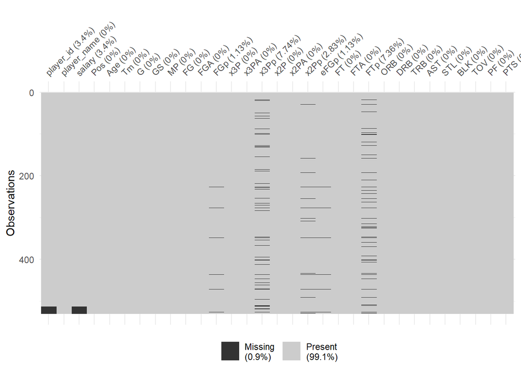

```r
naniar::vis_miss(nba_player_stats)
```

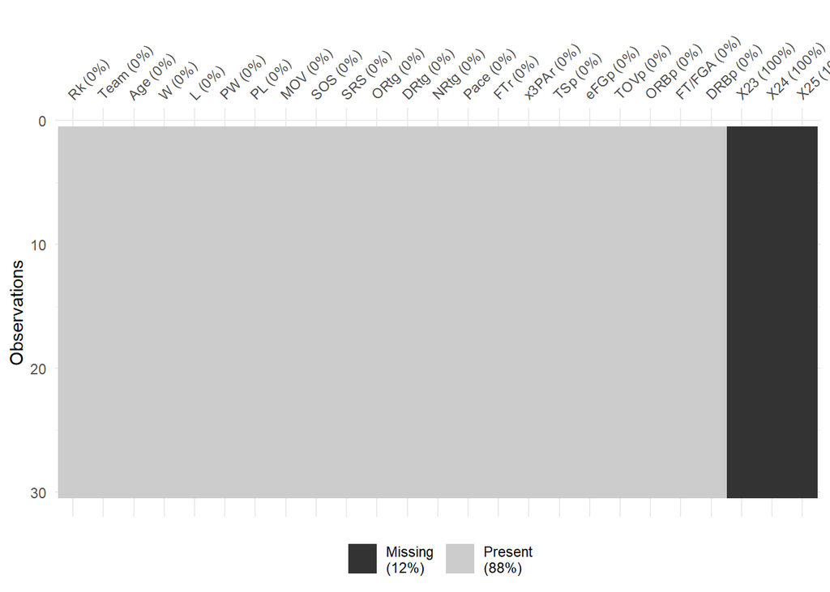

```r
naniar::vis_miss(nba_team_stats1)
```

```r
nba_player_stats <- replace_na(nba_player_stats, list(FGp = 0, x3Pp = 0, x2Pp = 0, eFGp = 0, FTp = 0))
nba_team_stats2 <- select(nba_team_stats2, -X23, -X24, -X25)
nba_team_stats1 <- select(nba_team_stats1, -X23, -X24, -X25)
sum(is.na(nba_player_stats)) #18 players have no salary data and will be treated post exploratory analysis
```

```
## [1] 36
```

```r
sum(is.na(nba_team_stats1))
```

```
## [1] 0
```

```r
sum(is.na(nba_team_stats2))
```

```
## [1] 0
```

## Exploratory Analysis

View summary statistics and bar charts of the variables in the Team Statistics and Team Player objects to ascertain the minimums, maximums, quartile ranges, mean, standard deviation and variability. The salary histogram seems quite skewed indicating there could be data quality issues.

```r
summary(nba_team_stats2)
```

```
##       Rank           Team                 G            MP              FG
##  Min.   : 1.00   Length:30          Min.   :82   Min.   :19705   Min.   :3113
##  1st Qu.: 8.25   Class :character   1st Qu.:82   1st Qu.:19780   1st Qu.:3272
##  Median :15.50   Mode  :character   Median :82   Median :19805   Median :3391
##  Mean   :15.50                      Mean   :82   Mean   :19815   Mean   :3369
##  3rd Qu.:22.75                      3rd Qu.:82   3rd Qu.:19855   3rd Qu.:3466
##  Max.   :30.00                      Max.   :82   Max.   :19980   Max.   :3612
##       FGA            FGp              x3P              x3PA
##  Min.   :6924   Min.   :0.4330   Min.   : 745.0   Min.   :2071
##  1st Qu.:7189   1st Qu.:0.4500   1st Qu.: 830.8   1st Qu.:2405
##  Median :7306   Median :0.4615   Median : 927.5   Median :2602
##  Mean   :7315   Mean   :0.4605   Mean   : 931.8   Mean   :2625
##  3rd Qu.:7424   3rd Qu.:0.4708   3rd Qu.:1009.5   3rd Qu.:2815
##  Max.   :7706   Max.   :0.4910   Max.   :1323.0   Max.   :3721
##       x3Pp             x2P            x2PA           x2Pp              FT
##  Min.   :0.3290   Min.   :1895   Min.   :3442   Min.   :0.4790   Min.   :1231
##  1st Qu.:0.3480   1st Qu.:2322   1st Qu.:4535   1st Qu.:0.5070   1st Qu.:1340
##  Median :0.3525   Median :2474   Median :4716   Median :0.5175   Median :1451
##  Mean   :0.3555   Mean   :2437   Mean   :4691   Mean   :0.5202   Mean   :1450
##  3rd Qu.:0.3590   3rd Qu.:2564   3rd Qu.:4998   3rd Qu.:0.5343   3rd Qu.:1532
##  Max.   :0.3920   Max.   :2739   Max.   :5182   Max.   :0.5650   Max.   :1853
##       FTA            FTp              ORB              DRB            TRB
##  Min.   :1575   Min.   :0.6950   Min.   : 718.0   Min.   :2563   Min.   :3311
##  1st Qu.:1741   1st Qu.:0.7482   1st Qu.: 794.5   1st Qu.:2769   1st Qu.:3607
##  Median :1900   Median :0.7715   Median : 833.5   Median :2864   Median :3720
##  Mean   :1892   Mean   :0.7670   Mean   : 848.5   Mean   :2855   Mean   :3704
##  3rd Qu.:1987   3rd Qu.:0.7917   3rd Qu.: 908.2   3rd Qu.:2932   3rd Qu.:3803
##  Max.   :2340   Max.   :0.8190   Max.   :1031.0   Max.   :3316   Max.   :4078
##       AST            STL             BLK             TOV             PF
##  Min.   :1646   Min.   :501.0   Min.   :195.0   Min.   : 992   Min.   :1487
##  1st Qu.:1917   1st Qu.:563.0   1st Qu.:380.5   1st Qu.:1103   1st Qu.:1653
##  Median :2016   Median :621.5   Median :415.5   Median :1148   Median :1712
##  Mean   :2016   Mean   :626.0   Mean   :406.2   Mean   :1155   Mean   :1714
##  3rd Qu.:2132   3rd Qu.:682.2   3rd Qu.:439.2   3rd Qu.:1204   3rd Qu.:1762
##  Max.   :2413   Max.   :766.0   Max.   :525.0   Max.   :1397   Max.   :1932
##       PTS            Age              W               L               PW
##  Min.   :8490   Min.   :23.40   Min.   :17.00   Min.   :22.00   Min.   :19.00
##  1st Qu.:8826   1st Qu.:25.48   1st Qu.:33.00   1st Qu.:32.25   1st Qu.:37.00
##  Median :9184   Median :26.30   Median :41.50   Median :40.50   Median :40.50
##  Mean   :9119   Mean   :26.28   Mean   :41.00   Mean   :41.00   Mean   :41.10
```

[output cut: 15 more lines]

```
##  Max.   :115.9   Max.   :117.6   Max.   : 8.600000   Max.   :103.90
##       FTr             x3PAr             TSp              eFGp
##  Min.   :0.2150   Min.   :0.2860   Min.   :0.5290   Min.   :0.4900
##  1st Qu.:0.2425   1st Qu.:0.3325   1st Qu.:0.5505   1st Qu.:0.5140
##  Median :0.2570   Median :0.3475   Median :0.5555   Median :0.5255
##  Mean   :0.2588   Mean   :0.3588   Mean   :0.5596   Mean   :0.5242
##  3rd Qu.:0.2692   3rd Qu.:0.3832   3rd Qu.:0.5710   3rd Qu.:0.5317
##  Max.   :0.3260   Max.   :0.5190   Max.   :0.5960   Max.   :0.5650
##       TOVp            ORBp           FT/FGA            DRBp
##  Min.   :10.90   Min.   :19.40   Min.   :0.1680   Min.   :72.50
##  1st Qu.:11.93   1st Qu.:21.75   1st Qu.:0.1825   1st Qu.:76.25
##  Median :12.40   Median :22.60   Median :0.1960   Median :77.10
##  Mean   :12.40   Mean   :22.89   Mean   :0.1983   Mean   :77.07
##  3rd Qu.:12.85   3rd Qu.:24.40   3rd Qu.:0.2100   3rd Qu.:77.97
##  Max.   :14.30   Max.   :26.60   Max.   :0.2580   Max.   :80.30
```

```r
summary(nba_player_stats)
```

```
##    player_id     player_name            salary             Pos
##  Min.   :  1.0   Length:530         Min.   :   47370   Length:530
##  1st Qu.:139.8   Class :character   1st Qu.: 1378242   Class :character
##  Median :283.5   Mode  :character   Median : 2756387   Mode  :character
##  Mean   :284.7                      Mean   : 6600874
##  3rd Qu.:424.2                      3rd Qu.: 9613438
##  Max.   :575.0                      Max.   :37457154
##  NA's   :18                         NA's   :18
##       Age            Tm                  G                GS
##  Min.   :19.0   Length:530         Min.   :  1.00   Min.   :  0.00
##  1st Qu.:23.0   Class :character   1st Qu.: 30.00   1st Qu.:  0.00
##  Median :25.0   Mode  :character   Median : 60.00   Median : 10.50
##  Mean   :25.9                      Mean   : 57.28   Mean   : 26.51
##  3rd Qu.:29.0                      3rd Qu.: 77.00   3rd Qu.: 51.00
##  Max.   :42.0                      Max.   :164.00   Max.   :164.00
##
##        MP               FG              FGA              FGp
##  Min.   :   1.0   Min.   :   0.0   Min.   :   0.0   Min.   :0.0000
##  1st Qu.: 359.8   1st Qu.:  49.0   1st Qu.: 110.0   1st Qu.:0.4120
##  Median :1174.0   Median : 175.0   Median : 372.0   Median :0.4600
##  Mean   :1298.8   Mean   : 217.3   Mean   : 474.8   Mean   :0.5756
##  3rd Qu.:2056.2   3rd Qu.: 335.8   3rd Qu.: 723.8   3rd Qu.:0.5490
##  Max.   :5694.0   Max.   :1222.0   Max.   :2508.0   Max.   :2.1990
##
##       x3P              x3PA             x3Pp             x2P
##  Min.   :  0.00   Min.   :   0.0   Min.   :0.0000   Min.   :  0.0
##  1st Qu.:  4.25   1st Qu.:  17.0   1st Qu.:0.2595   1st Qu.: 32.0
##  Median : 34.00   Median : 105.0   Median :0.3390   Median :107.0
##  Mean   : 61.61   Mean   : 173.8   Mean   :0.3869   Mean   :155.7
##  3rd Qu.: 97.50   3rd Qu.: 273.0   3rd Qu.:0.3970   3rd Qu.:226.5
##  Max.   :378.00   Max.   :1028.0   Max.   :1.8260   Max.   :910.0
##
##       x2PA              x2Pp             eFGp              FT
##  Min.   :   0.00   Min.   :0.0000   Min.   :0.0000   Min.   :  0.00
##  1st Qu.:  63.75   1st Qu.:0.4650   1st Qu.:0.4793   1st Qu.: 17.00
##  Median : 209.00   Median :0.5235   Median :0.5270   Median : 55.50
##  Mean   : 300.99   Mean   :0.6361   Mean   :0.6587   Mean   : 93.34
##  3rd Qu.: 447.75   3rd Qu.:0.6028   3rd Qu.:0.5940   3rd Qu.:134.75
##  Max.   :1722.00   Max.   :2.2530   Max.   :2.4900   Max.   :754.00
##
```

[output cut: 9 more lines]

```
##  Min.   :   0.0   Min.   :  0.0   Min.   :  0.00   Min.   :  0.00
##  1st Qu.:  60.0   1st Qu.: 22.0   1st Qu.: 10.00   1st Qu.:  4.00
##  Median : 189.0   Median : 84.5   Median : 31.00   Median : 16.00
##  Mean   : 240.6   Mean   :128.7   Mean   : 40.85   Mean   : 25.77
##  3rd Qu.: 333.0   3rd Qu.:186.0   3rd Qu.: 61.00   3rd Qu.: 34.00
##  Max.   :1804.0   Max.   :784.0   Max.   :246.00   Max.   :199.00
##
##       TOV              PF              PTS
##  Min.   :  0.0   Min.   :  0.00   Min.   :   0.0
##  1st Qu.: 16.0   1st Qu.: 37.25   1st Qu.: 130.0
##  Median : 52.0   Median :104.00   Median : 457.0
##  Mean   : 71.5   Mean   :112.35   Mean   : 589.5
##  3rd Qu.:104.8   3rd Qu.:171.00   3rd Qu.: 914.5
##  Max.   :387.0   Max.   :434.00   Max.   :3288.0
##
```

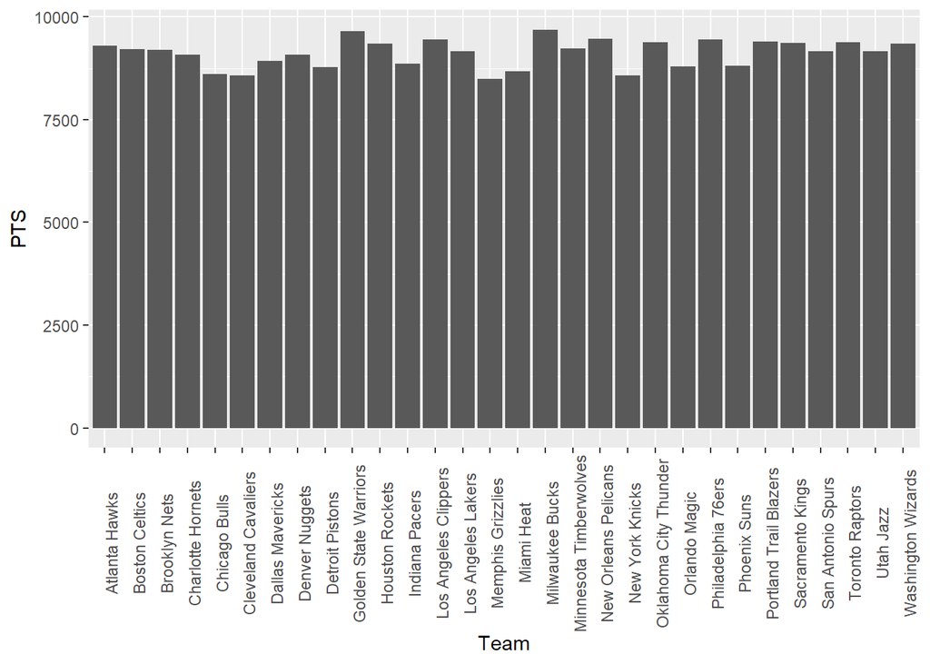

```r
nba_team_stats2 %>%
  ggplot(aes(x = Team, y = PTS)) +
  geom_bar(stat = "identity") +
  theme(axis.text.x = element_text(angle = 90))
```

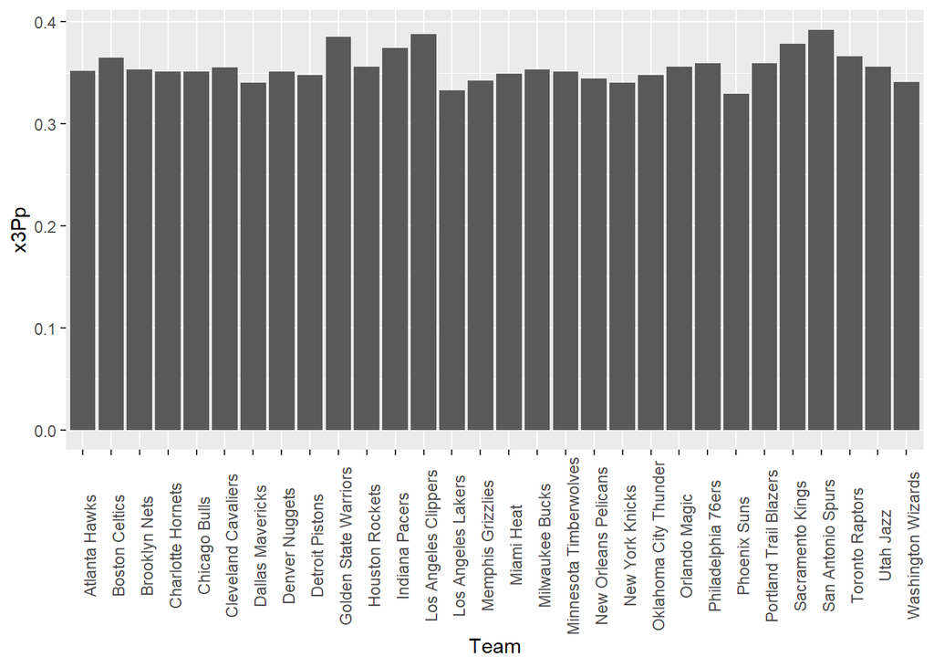

```r
nba_team_stats2 %>%
  ggplot(aes(x = Team, y = x3Pp)) +
  geom_bar(stat = "identity") +
  theme(axis.text.x = element_text(angle = 90))
```

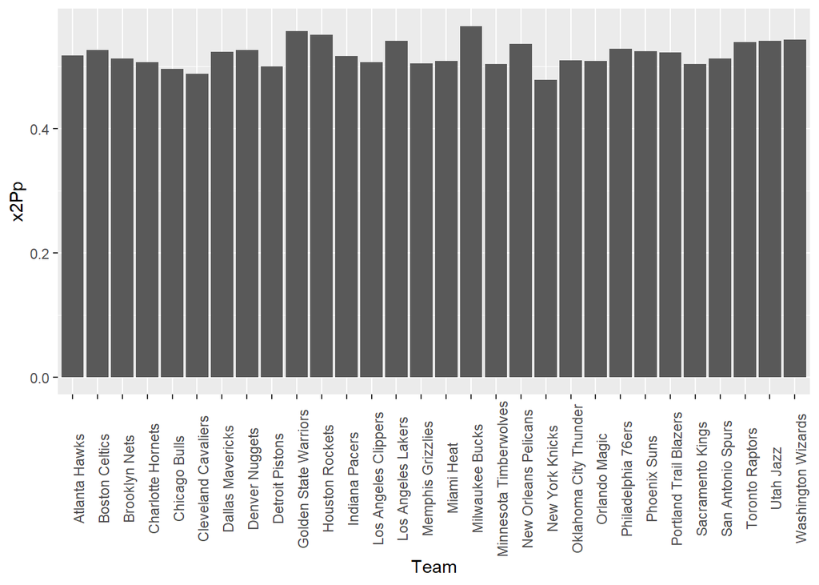

```r
nba_team_stats2 %>%
  ggplot(aes(x = Team, y = x2Pp)) +
  geom_bar(stat = "identity") +
  theme(axis.text.x = element_text(angle = 90))
```

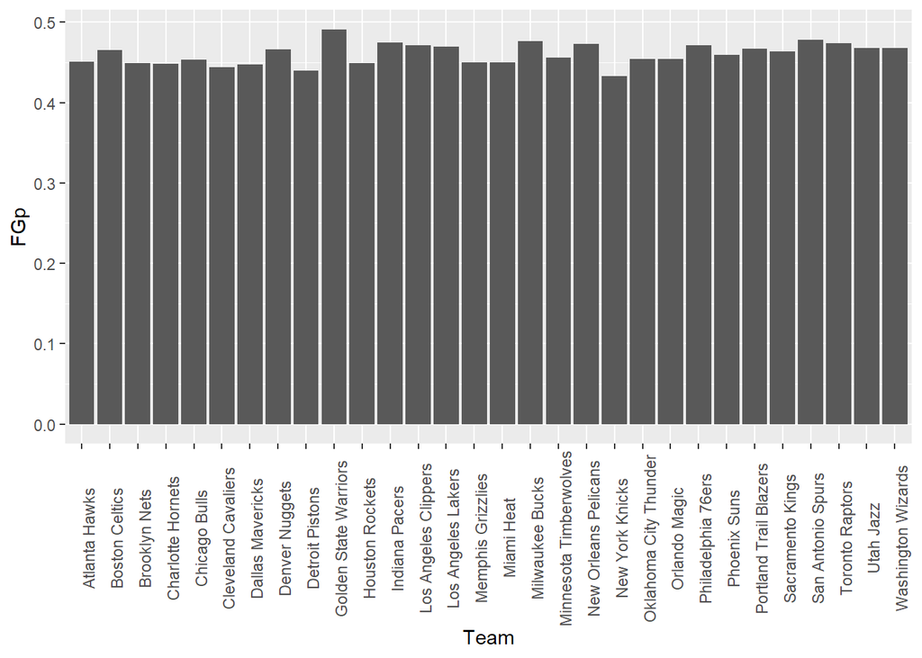

```r
nba_team_stats2 %>%
  ggplot(aes(x = Team, y = FGp)) +
  geom_bar(stat = "identity") +
  theme(axis.text.x = element_text(angle = 90))
```

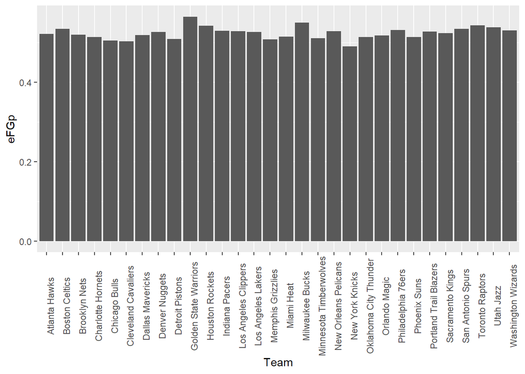

```r
nba_team_stats2 %>%
  ggplot(aes(x = Team, y = eFGp)) +
  geom_bar(stat = "identity") +
  theme(axis.text.x = element_text(angle = 90))
```

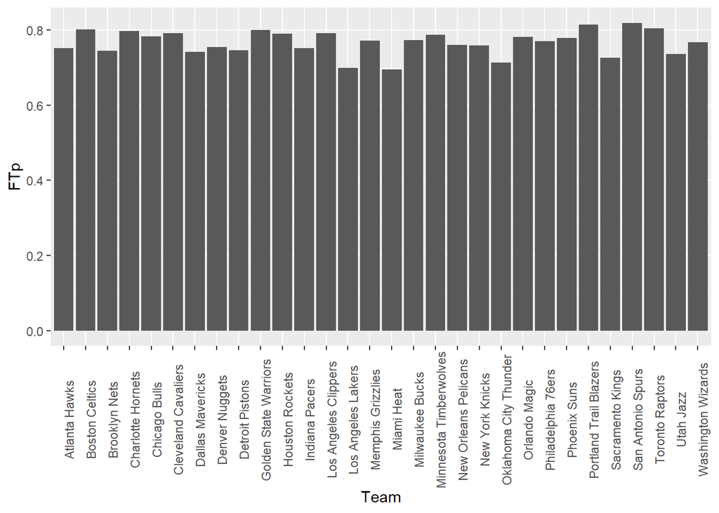

```r
nba_team_stats2 %>%
  ggplot(aes(x = Team, y = FTp)) +
  geom_bar(stat = "identity") +
  theme(axis.text.x = element_text(angle = 90))
```

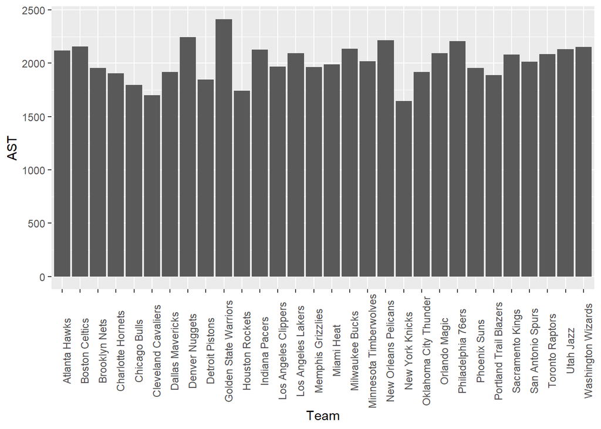

```r
nba_team_stats2 %>%
  ggplot(aes(x = Team, y = AST)) +
  geom_bar(stat = "identity") +
  theme(axis.text.x = element_text(angle = 90))
```

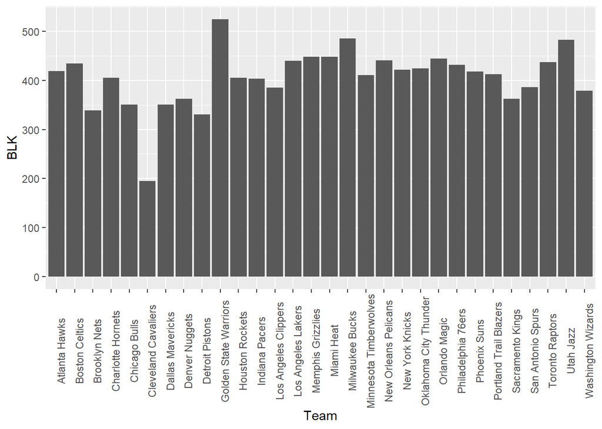

```r
nba_team_stats2 %>%
  ggplot(aes(x = Team, y = BLK)) +
  geom_bar(stat = "identity") +
  theme(axis.text.x = element_text(angle = 90))
```

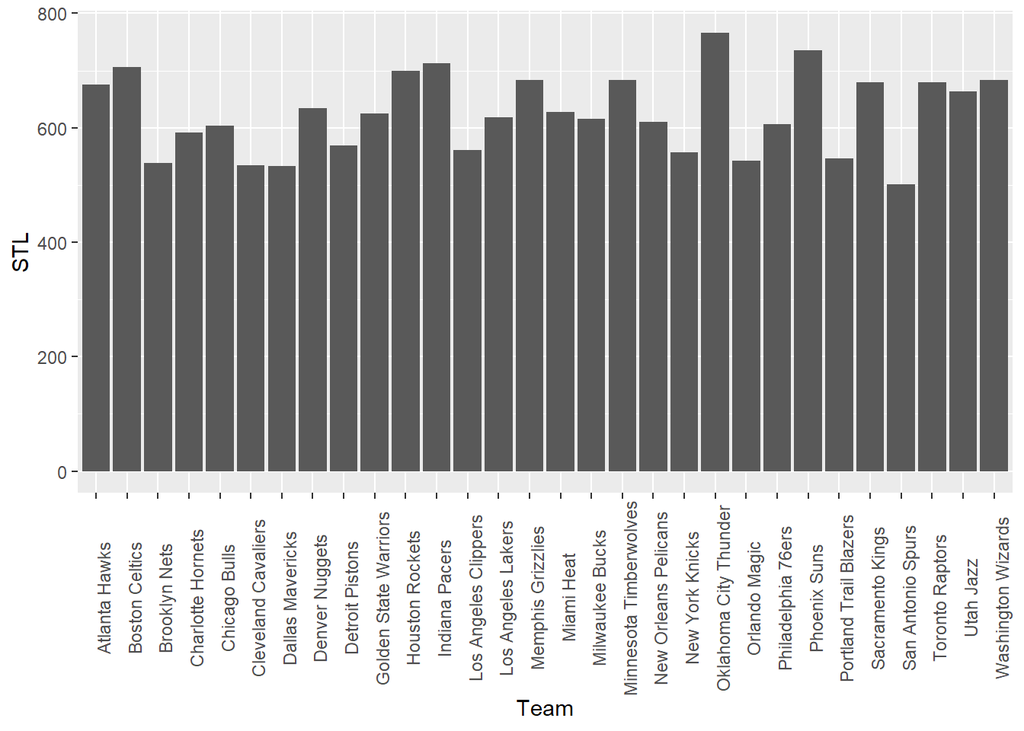

```r
nba_team_stats2 %>%
  ggplot(aes(x = Team, y = STL)) +
  geom_bar(stat = "identity") +
  theme(axis.text.x = element_text(angle = 90))
```

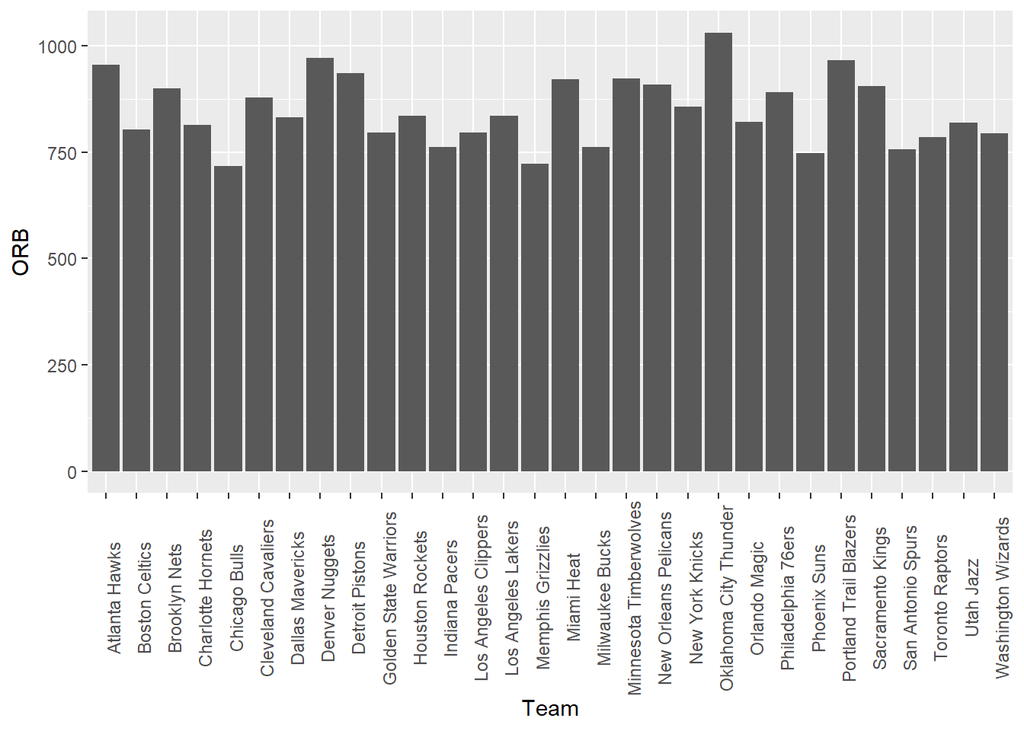

```r
nba_team_stats2 %>%
  ggplot(aes(x = Team, y = ORB)) +
  geom_bar(stat = "identity") +
  theme(axis.text.x = element_text(angle = 90))
```

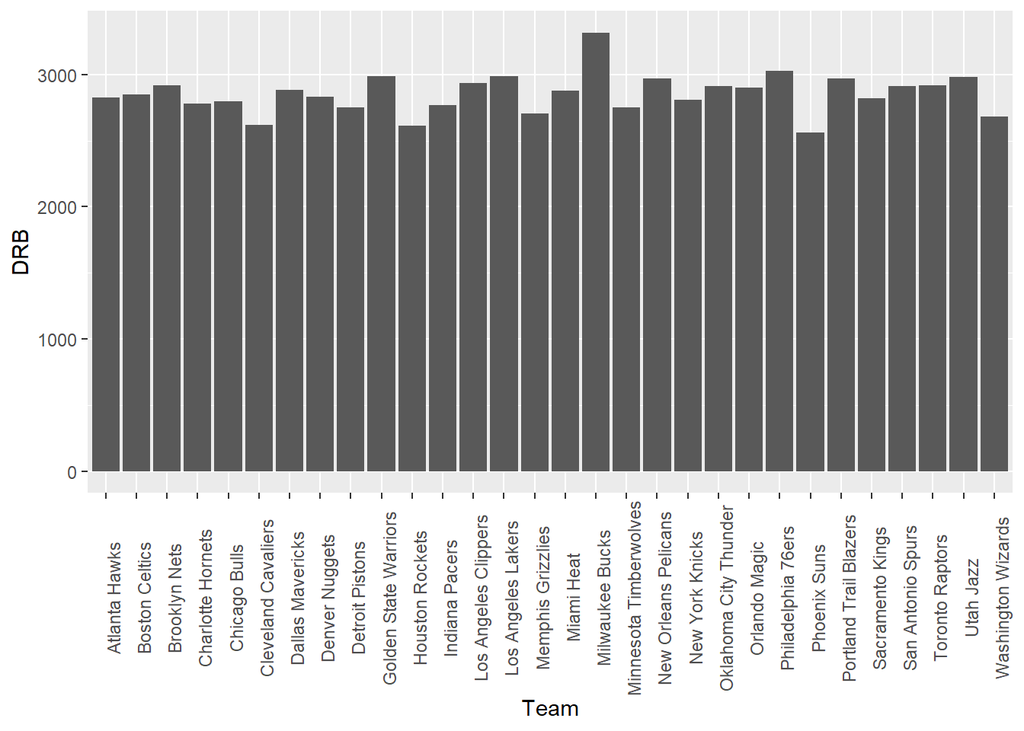

```r
nba_team_stats2 %>%
  ggplot(aes(x = Team, y = DRB)) +
  geom_bar(stat = "identity") +
  theme(axis.text.x = element_text(angle = 90))
```

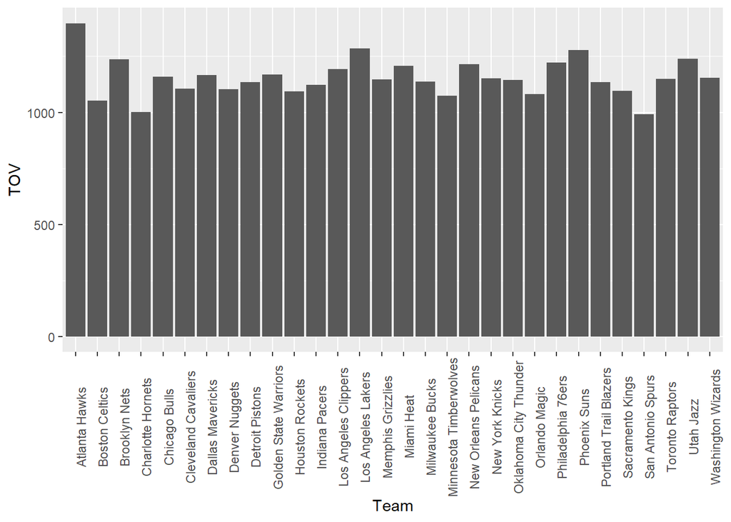

```r
nba_team_stats2 %>%
  ggplot(aes(x = Team, y = TOV)) +
  geom_bar(stat = "identity") +
  theme(axis.text.x = element_text(angle = 90))
```

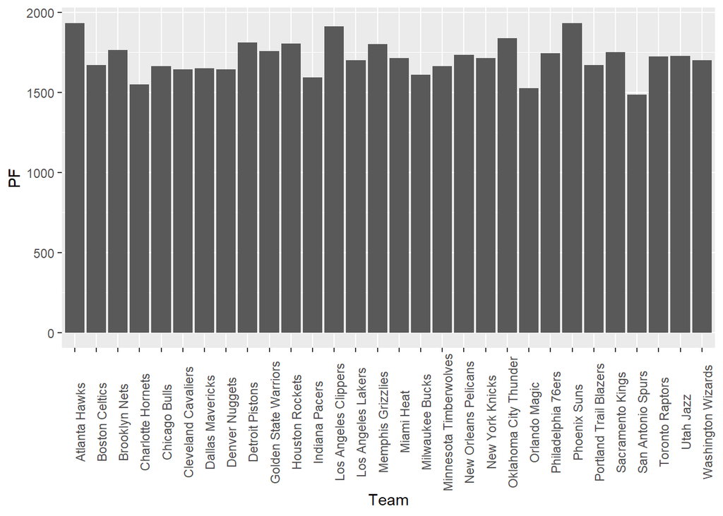

```r
nba_team_stats2 %>%
  ggplot(aes(x = Team, y = PF)) +
  geom_bar(stat = "identity") +
  theme(axis.text.x = element_text(angle = 90))
```

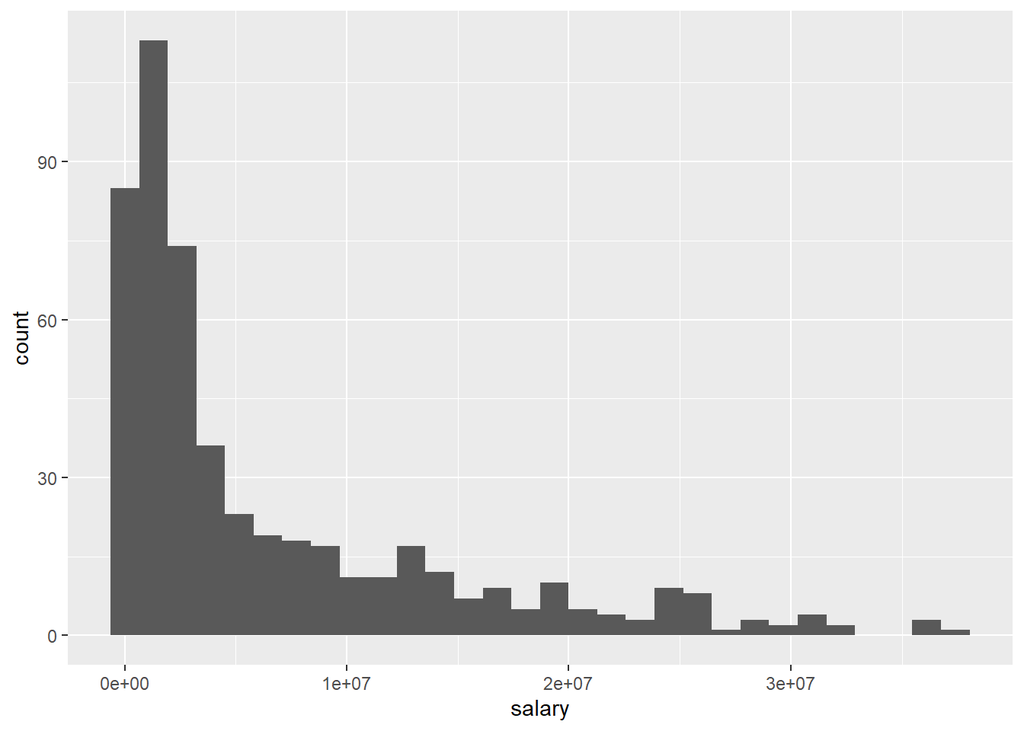

```r
ggplot(data = nba_player_stats) +
  geom_histogram(aes(x = salary))
```

View mean and standard deviations for players and teams of percentage of 3-point, 2-point, Free Throw and Field Goal variables

```r
nba_team_stats2 %>%
  dplyr::summarise(mnFGp = mean(FGp),
          mnx3Pp = mean(x3Pp),
          mnx2Pp = mean(x2Pp),
          mneFGp = mean(eFGp),
          mnFTp = mean(FTp),
          sdFGp = sd(FGp),
          sdx3Pp = sd(x3Pp),
          sdx2Pp = sd(x2Pp),
          sdeFGp = sd(eFGp),
          sdFTp = sd(FTp))
```

```
## # A tibble: 1 x 10
##   mnFGp mnx3Pp mnx2Pp mneFGp mnFTp  sdFGp sdx3Pp sdx2Pp sdeFGp  sdFTp
##   <dbl>  <dbl>  <dbl>  <dbl> <dbl>  <dbl>  <dbl>  <dbl>  <dbl>  <dbl>
## 1 0.460  0.356  0.520  0.524 0.767 0.0132 0.0153 0.0202 0.0152 0.0322
```

```r
nba_player_stats %>%
  dplyr::group_by(Pos) %>%
  dplyr::summarise(mnFGp = mean(FGp),
         mnx3Pp = mean(x3Pp),
         mnx2Pp = mean(x2Pp),
         mneFGp = mean(eFGp),
         mnFTp = mean(FTp),
         sdFGp = sd(FGp),
         sdx3Pp = sd(x3Pp),
         sdx2Pp = sd(x2Pp),
         sdeFGp = sd(eFGp),
         sdFTp = sd(FTp))
```

```
## # A tibble: 5 x 11
##   Pos   mnFGp mnx3Pp mnx2Pp mneFGp mnFTp sdFGp sdx3Pp sdx2Pp sdeFGp sdFTp
##   <chr> <dbl>  <dbl>  <dbl>  <dbl> <dbl> <dbl>  <dbl>  <dbl>  <dbl> <dbl>
## 1 C     0.662  0.227  0.688  0.689 0.823 0.403  0.287  0.398  0.413 0.569
## 2 PF    0.591  0.406  0.675  0.678 0.943 0.360  0.352  0.393  0.417 0.635
## 3 PG    0.524  0.412  0.577  0.605 0.877 0.304  0.265  0.374  0.357 0.567
## 4 SF    0.591  0.447  0.679  0.696 0.914 0.354  0.306  0.424  0.424 0.656
## 5 SG    0.534  0.426  0.588  0.642 0.884 0.323  0.303  0.363  0.411 0.663
```

Create separate object for players filtered by position, and compare the mean scoring percentages for that position with the player’s scoring percentage

```r
#Filter by position
center <- nba_player_stats %>%
  filter(Pos == "C") %>%
  mutate(comparison_FGp = if_else(FGp > mean(FGp), "better", "worse"), comparison_x3Pp = if_else(x3Pp > mean(x3Pp), "better", "worse"), comparison_x2Pp = if_else(x2Pp > mean(x2Pp), "better", "worse"), comparison_eFGp = if_else(eFGp > mean(eFGp), "better", "worse"), comparison_FTp = if_else(FTp > mean(FTp), "better", "worse"))
point_guard <- nba_player_stats %>%
  filter(Pos == "PG") %>%
  mutate(comparison_FGp = if_else(FGp > mean(FGp), "better", "worse"), comparison_x3Pp = if_else(x3Pp > mean(x3Pp), "better", "worse"), comparison_x2Pp = if_else(x2Pp > mean(x2Pp), "better", "worse"), comparison_eFGp = if_else(eFGp > mean(eFGp), "better", "worse"), comparison_FTp = if_else(FTp > mean(FTp), "better", "worse"))
shooting_guard <- nba_player_stats %>%
  filter(Pos == "SG") %>%
  mutate(comparison_FGp = if_else(FGp > mean(FGp), "better", "worse"), comparison_x3Pp = if_else(x3Pp > mean(x3Pp), "better", "worse"), comparison_x2Pp = if_else(x2Pp > mean(x2Pp), "better", "worse"), comparison_eFGp = if_else(eFGp > mean(eFGp), "better", "worse"), comparison_FTp = if_else(FTp > mean(FTp), "better", "worse"))
small_forward <- nba_player_stats %>%
  filter(Pos == "SF") %>%
  mutate(comparison_FGp = if_else(FGp > mean(FGp), "better", "worse"), comparison_x3Pp = if_else(x3Pp > mean(x3Pp), "better", "worse"), comparison_x2Pp = if_else(x2Pp > mean(x2Pp), "better", "worse"), comparison_eFGp = if_else(eFGp > mean(eFGp), "better", "worse"), comparison_FTp = if_else(FTp > mean(FTp), "better", "worse"))
power_forward <- nba_player_stats %>%
  filter(Pos == "PF") %>%
  mutate(comparison_FGp = if_else(FGp > mean(FGp), "better", "worse"), comparison_x3Pp = if_else(x3Pp > mean(x3Pp), "better", "worse"), comparison_x2Pp = if_else(x2Pp > mean(x2Pp), "better", "worse"), comparison_eFGp = if_else(eFGp > mean(eFGp), "better", "worse"), comparison_FTp = if_else(FTp > mean(FTp), "better", "worse"))
```

Create per game data for each teams and visualise

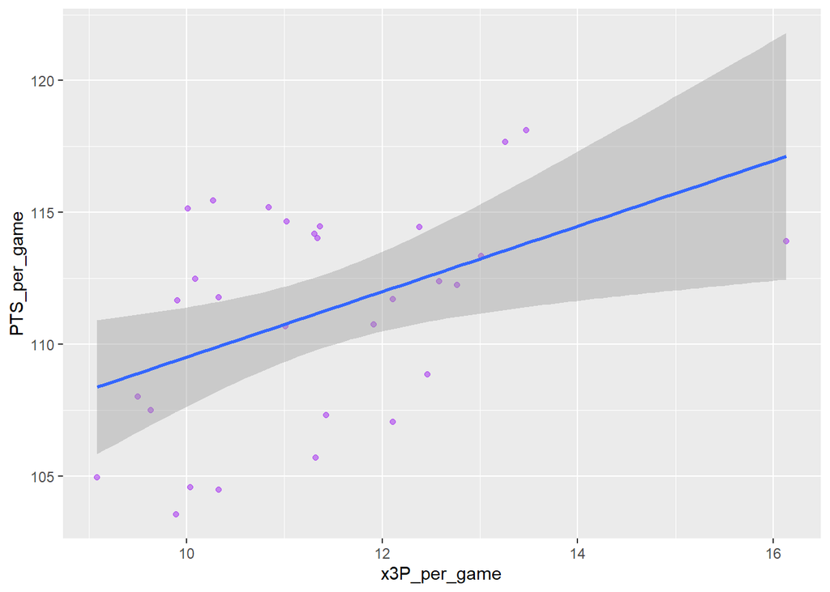

```r
nba_team_stats2 <- nba_team_stats2 %>%
  mutate(FG_per_game = FG / G,
         x3P_per_game = x3P / G,
         x2P_per_game = x2P / G,
         FT_per_game = FT / G,
         PTS_per_game = PTS / G,
         AST_per_game = AST / G,
         STL_per_game = STL / G,
         BLK_per_game = BLK / G,
         ORB_per_game = ORB / G,
         DRB_per_game = DRB / G,
         TOV_per_game = TOV / G,
         PF_per_game = PF / G,)

ggplot(nba_team_stats2, aes(x = x3P_per_game, y = PTS_per_game)) +
  geom_point(alpha = 0.5, colour = "purple") +
  geom_smooth(method = "lm")
```

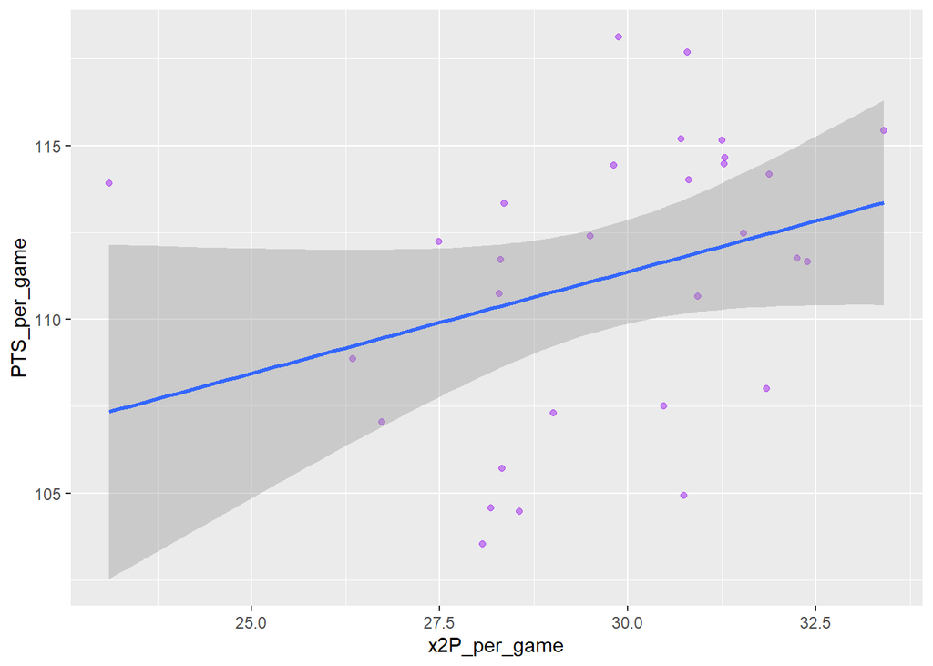

```r
ggplot(nba_team_stats2, aes(x = x2P_per_game, y = PTS_per_game)) +
  geom_point(alpha = 0.5, colour = "purple") +
  geom_smooth(method = "lm")
```

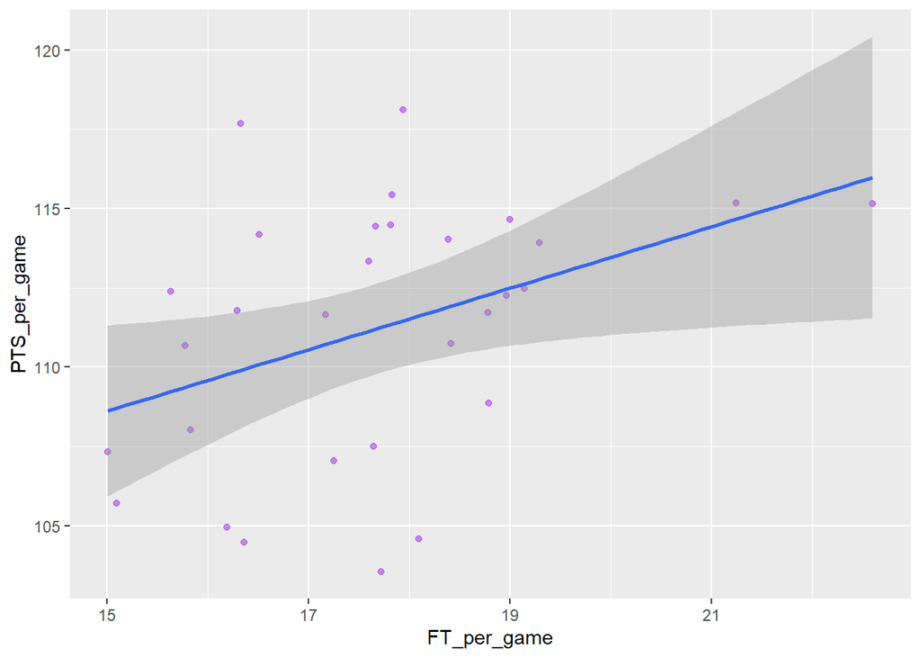

```r
ggplot(nba_team_stats2, aes(x = FT_per_game, y = PTS_per_game)) +
  geom_point(alpha = 0.5, colour = "purple") +
  geom_smooth(method = "lm")
```

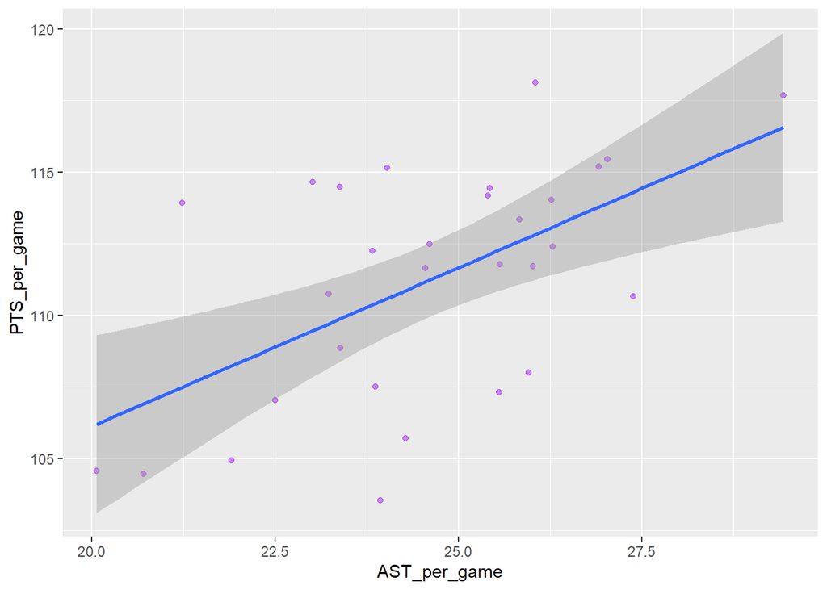

```r
ggplot(nba_team_stats2, aes(x = AST_per_game, y = PTS_per_game)) +
  geom_point(alpha = 0.5, colour = "purple") +
  geom_smooth(method = "lm")
```

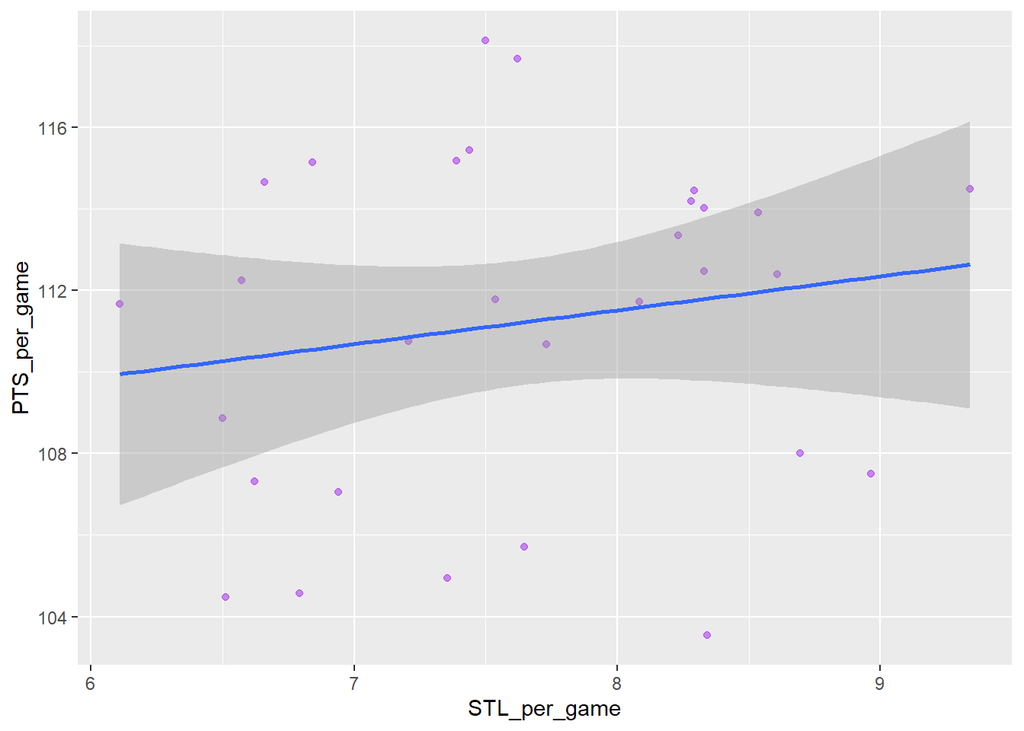

```r
ggplot(nba_team_stats2, aes(x = STL_per_game, y = PTS_per_game)) +
  geom_point(alpha = 0.5, colour = "purple") +
  geom_smooth(method = "lm")
```

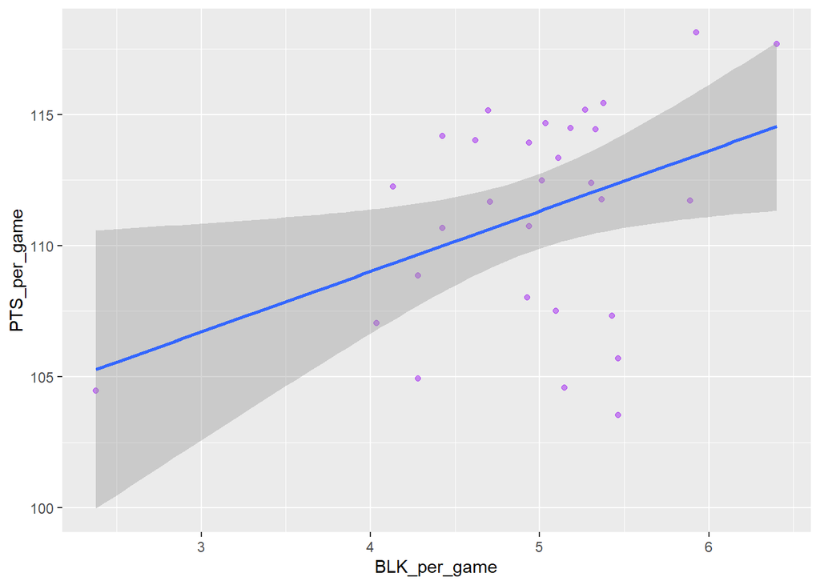

```r
ggplot(nba_team_stats2, aes(x = BLK_per_game, y = PTS_per_game)) +
  geom_point(alpha = 0.5, colour = "purple") +
  geom_smooth(method = "lm")
```

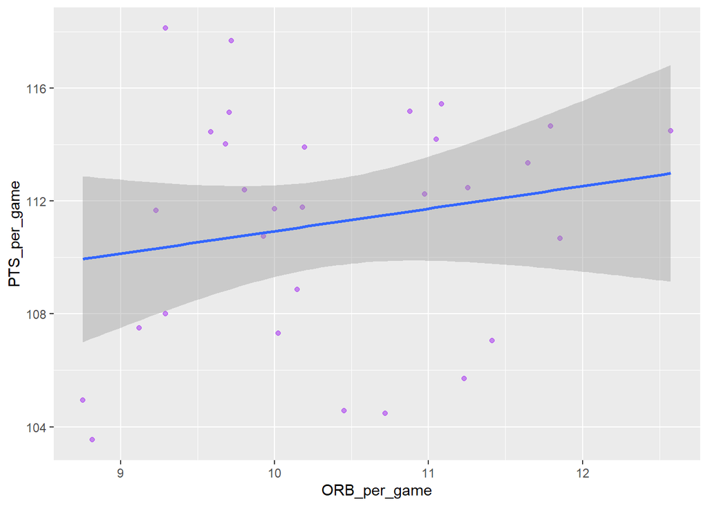

```r
ggplot(nba_team_stats2, aes(x = ORB_per_game, y = PTS_per_game)) +
  geom_point(alpha = 0.5, colour = "purple") +
  geom_smooth(method = "lm")
```

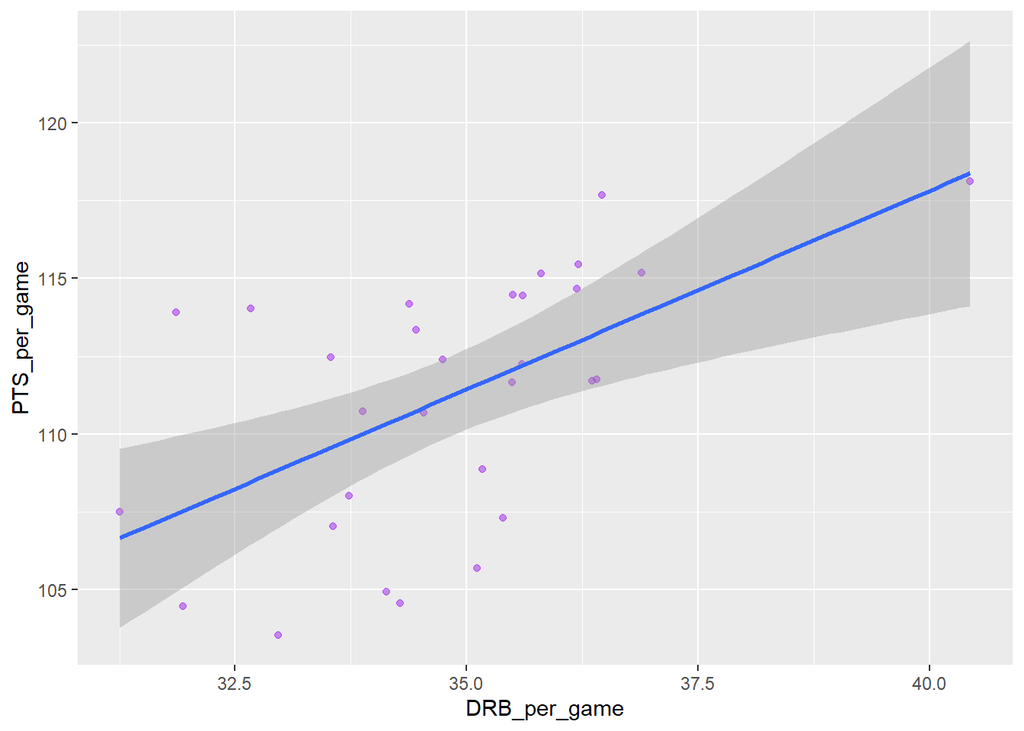

```r
ggplot(nba_team_stats2, aes(x = DRB_per_game, y = PTS_per_game)) +
  geom_point(alpha = 0.5, colour = "purple") +
  geom_smooth(method = "lm")
```

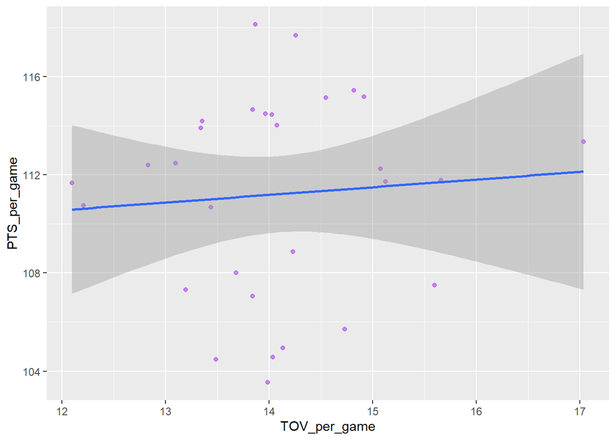

```r
ggplot(nba_team_stats2, aes(x = TOV_per_game, y = PTS_per_game)) +
  geom_point(alpha = 0.5, colour = "purple") +
  geom_smooth(method = "lm")
```

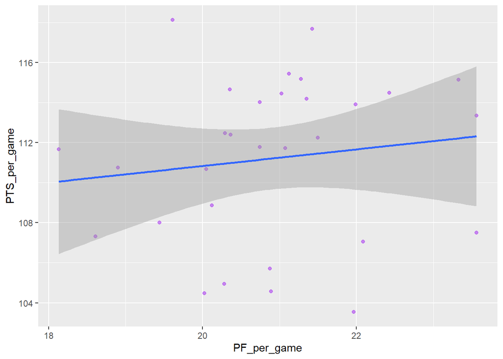

```r
ggplot(nba_team_stats2, aes(x = PF_per_game, y = PTS_per_game)) +
  geom_point(alpha = 0.5, colour = "purple") +
  geom_smooth(method = "lm")
```

Based on the exploratory analysis, there is very little difference between each of the teams in the point metrics, and scoring points obviously has a strong relationship with increasing points per game.

The modelling conducted further below will hence focus on the other data such as assists, blocks, steals, offensive and defensive rebounds, turnovers and fouls to see these variables’ impact on total points per game, to ascertain which variables have the most impact, and which players could most contribute in these areas to increase total points, which will potentially result in more games won.

### Modelling

Create linear regression model using assists, blocks, steals, offensive and defensive rebounds, turnovers and fouls variables.

The variables with the strongest positive impact on points per game are defensive rebounds (for every one defensive rebound, a team will be expected to score 1.43 more points); assists (for every assist, a team will be expected to score 0.84 more points); and personal fouls (for every personal foul, a team can be expected to score 1.67 more points). Turnovers has a strong negative impact on total points with a team expected to score 1.84 points less for each turnover. The confidence intervals for these variables are also both positive. The other variables are harder to interpret whether there is a positive or negative relationship given the confidence intervals go from negative to positive.

We thus want to find the players that have higher numbers of defensive rebounds, personal fouls, and assists, with a lower number of turnovers.

```r
fit <- lm(PTS_per_game ~ ORB_per_game + DRB_per_game + AST_per_game + STL_per_game + BLK_per_game + TOV_per_game + PF_per_game, data = nba_team_stats2)
tidy(fit, conf.int = TRUE)
```

```
## # A tibble: 8 x 7
##   term         estimate std.error statistic p.value conf.low conf.high
##   <chr>           <dbl>     <dbl>     <dbl>   <dbl>    <dbl>     <dbl>
## 1 (Intercept)    26.5      17.6       1.51  0.146     -9.93     62.9
## 2 ORB_per_game    0.393     0.598     0.657 0.518     -0.847     1.63
## 3 DRB_per_game    1.44      0.467     3.08  0.00550    0.469     2.41
## 4 AST_per_game    0.835     0.344     2.43  0.0239     0.122     1.55
## 5 STL_per_game    0.592     0.934     0.634 0.533     -1.34      2.53
## 6 BLK_per_game   -0.727     1.15     -0.635 0.532     -3.10      1.65
## 7 TOV_per_game   -1.84      0.796    -2.31  0.0307    -3.49     -0.187
## 8 PF_per_game     1.68      0.682     2.46  0.0224     0.261     3.09
```

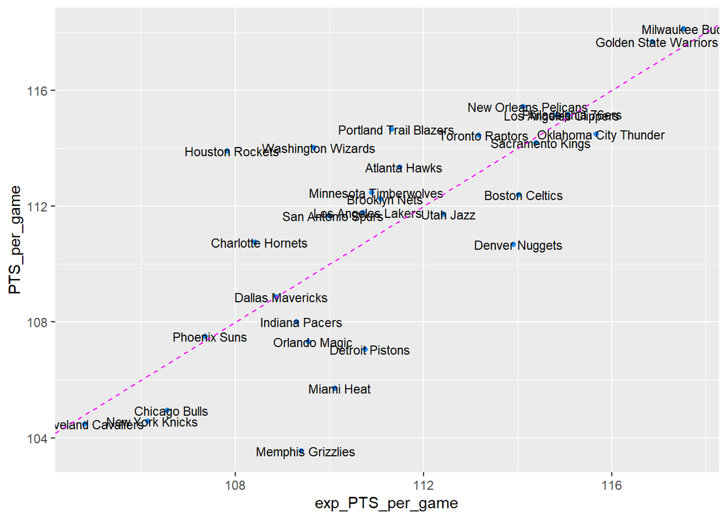

```r
nba_team_stats2 <- mutate(nba_team_stats2, exp_PTS_per_game = predict(fit, newdata = nba_team_stats2))

ggplot(nba_team_stats2, aes(exp_PTS_per_game, PTS_per_game, label = Team)) +
  geom_point(colour = "dodgerblue") +
  geom_text(nudge_x = 0.1, cex = 3) +
  geom_abline(linetype = "dashed", colour = "magenta")
```

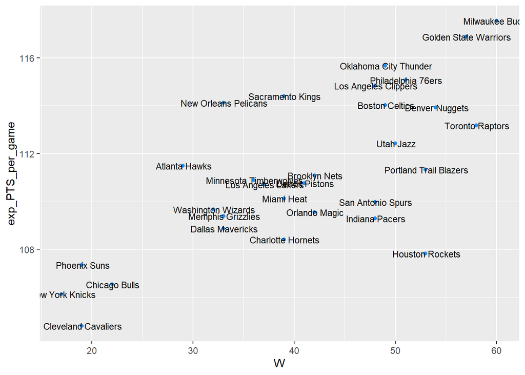

```r
ggplot(nba_team_stats2, aes(x = W, y = exp_PTS_per_game, label = Team)) +
  geom_point(colour = "dodgerblue") +
  geom_text(nudge_x = 0.1, cex = 3)
```

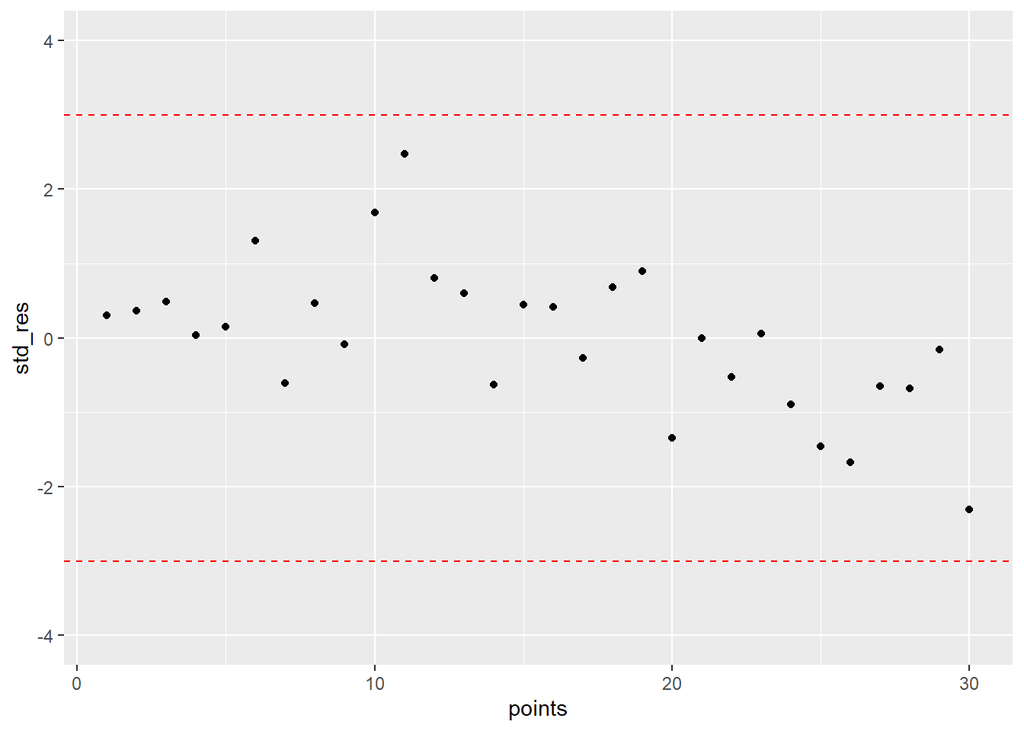

```r
std_res <- rstandard(fit)
points <- 1:length(std_res)

ggplot(data = NULL, aes(x = points, y = std_res)) +
geom_point() +
ylim(c(-4,4)) +
geom_hline(yintercept = c(-3, 3), colour = "red", linetype = "dashed")
```

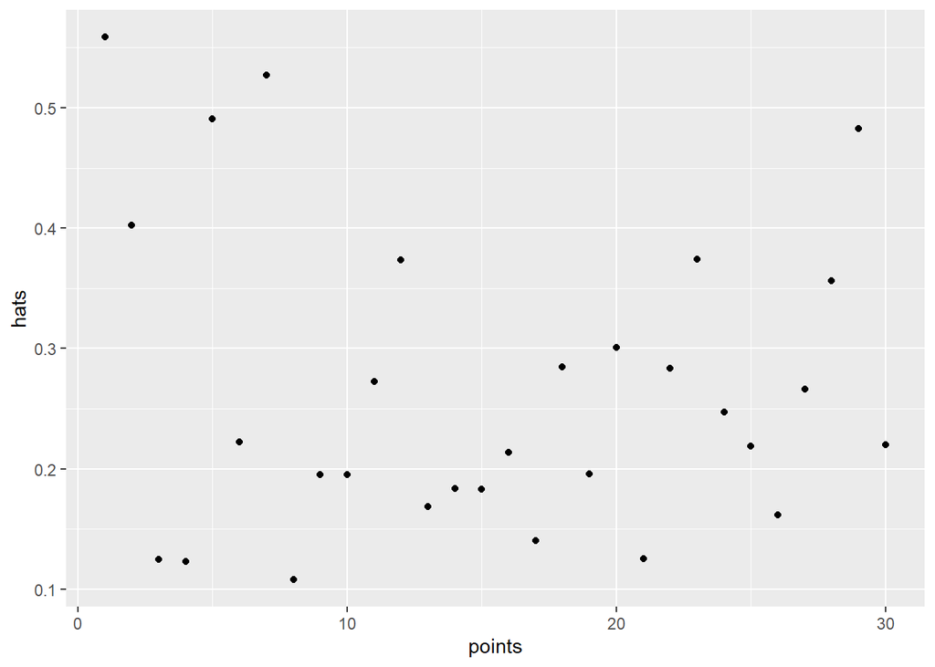

```r
hats <- hatvalues(fit)
ggplot(data = NULL, aes(x = points, y = hats)) +
geom_point()
```

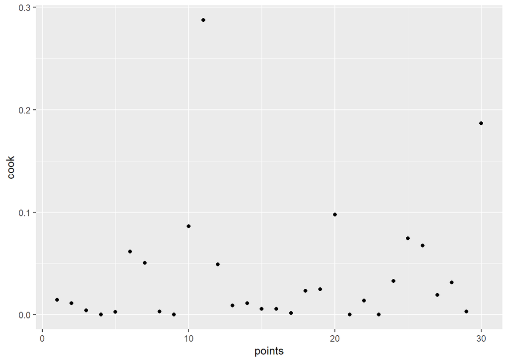

```r
cook <- cooks.distance(fit)
ggplot(data = NULL, aes(x = points, y = cook)) +
geom_point()
```

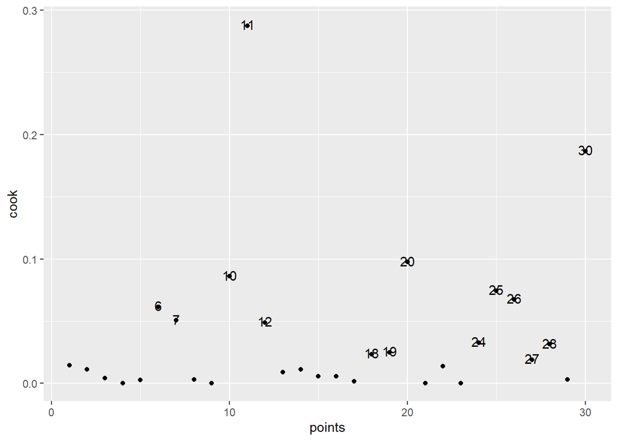

```r
cook_labels <- if_else(cook >= 0.015, paste(points), "")
ggplot(data = NULL, aes(x = points, y = cook)) +
geom_point() +
geom_text(aes(label = cook_labels), nudge_y = 0.001)
```